# AnaliseCEAP

Emanoel Barros

1 de novembro de 2017

# Análise de Gastos de Deputados: Nossas Perguntas

Importando pacotes que serão utilizados e carregando os dados:

```r
library(dplyr)
library(tidyr)
```

```r
library(ggplot2)
dadosCEAP <- read.csv("../../../Documents/dadosCEAP.csv", encoding = "UTF-8")
```

**1. Quais os partidos que mais fazem uso da CEAP? Quais os partidos que menos fazem uso?**

Para responder a essa questão, os atributos **sgPartido** e **valorLíquido** serão filtrados:

```r
gastos_por_partido <- dadosCEAP %>% select(sgPartido, valorLíquido) %>%
                 group_by(sgPartido) %>% summarise(gasto_total_partido = sum(valorLíquido)) %>%
  arrange(desc(gasto_total_partido))
```

Um gráfico de barras é plotado com os gastos de cada partido em ordem decrescente:

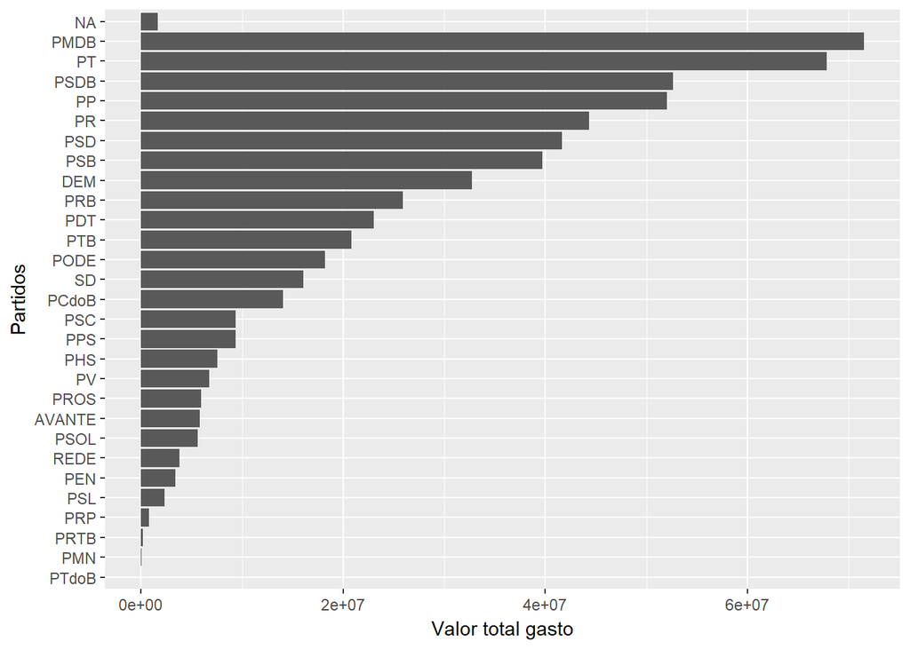

```r
ggplot(gastos_por_partido, aes(x = reorder(sgPartido, gasto_total_partido), y = gasto_total_partido), options(scipen = 5)) +
  geom_bar(stat = "identity") +
  xlab("Partidos") + #eixo X
  ylab("Valor total gasto") + #eixo Y
  coord_flip()
```

Decidiu-se manter os gastos de **NA** caso fosse necessário usá-lo depois.

2. Quais os tipos de despesa mais comuns no uso da CEAP? Mesma pergunta considerando valores em R$.

Para responder essa pergunta, filtra-se o atributo **tipoDespesa** e verifica-se a ocorrência de cada tipo:

```r
tipo_despesa <- dadosCEAP %>%
  select(tipoDespesa) %>%
  group_by(tipoDespesa) %>%
  summarise(n_despesa = n()) %>%
  arrange(desc(n_despesa))
```

Plota-se um gráfico de barras para melhor analisar o número de cada tipo de despesa:

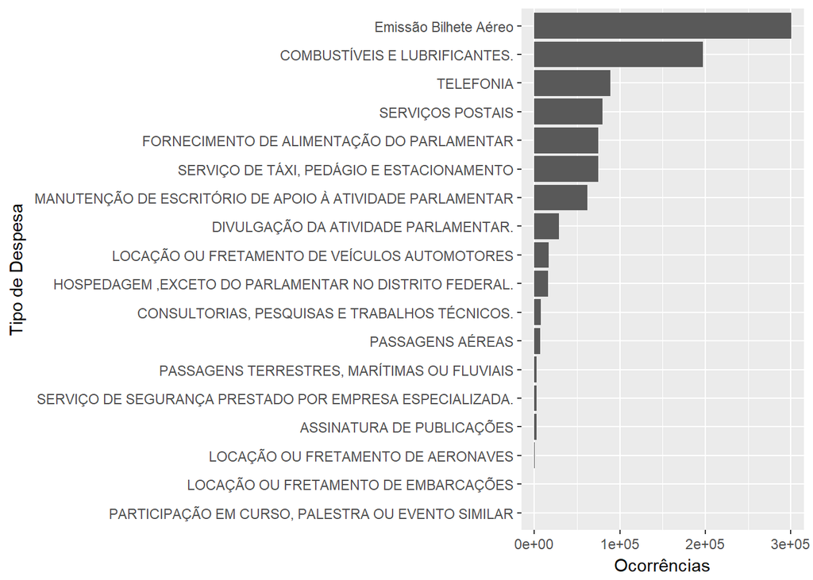

```r
ggplot(tipo_despesa, aes(x = reorder(tipoDespesa, n_despesa), y = n_despesa), options(scipen = 5)) +
  geom_bar(stat = "identity") +
  xlab("Tipo de Despesa") + #eixo X
  ylab("Ocorrências") + #eixo Y
  coord_flip()
```

A partir do gráfico, é possível perceber que o tipo mais comum de despesa é a Emissão de Bilhete Aéreo.

3. Levando em conta o estado pelo qual o deputado se elegeu, quais os estados que mais fazem uso da CEAP? Quais os que menos fazem uso? Mesmas perguntas considerando gastos em R$. Por que você acha isso?

Observaremos os atributos **sgUF** e **valorLíquido** apenas:

```r
gastos_por_estado <- dadosCEAP %>%
  select(sgUF, valorLíquido) %>%
  group_by(sgUF) %>%
  summarise(gasto_total_estado = sum(valorLíquido)) %>%
  arrange(desc(gasto_total_estado))
```

Plotando o gráfico de barras em ordem decrescente, tem-se:

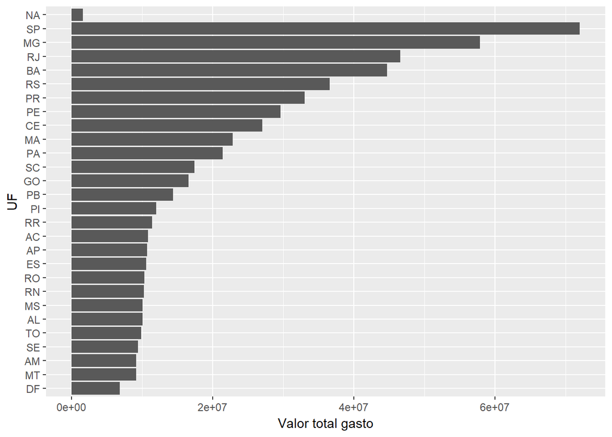

```r
ggplot(gastos_por_estado, aes(x = reorder(sgUF, gasto_total_estado), y = gasto_total_estado), options(scipen = 5)) +
  geom_bar(stat = "identity") +
  xlab("UF") + #eixo X
  ylab("Valor total gasto") + #eixo Y
  coord_flip()
```

**São Paulo** e **Minas Gerais** são os estados que mais usam, enquanto o **Distrito Federal** é quem menos usa. Acredita-se que o uso do CEAP por estado tem uma relação direta com o número de deputados pertencentes a cada estado.

4. Quais os parlamentares que mais gastam com CEAP e quais os que menos gastam?

Extrai-se os 10 parlamentares que mais gastam e os 10 que menos gastam:

```r
dep_por_gastos <- dadosCEAP %>% select(nomeParlamentar, valorLíquido) %>%
  group_by(nomeParlamentar) %>%
  summarise(gasto_total_dep = sum(valorLíquido)) %>%
  arrange(desc(gasto_total_dep))

dep_mais_gastam <- dep_por_gastos %>% head(10)
dep_menos_gastam <- dep_por_gastos %>% tail(10) %>% arrange(gasto_total_dep)
```

Dado o grande número de deputados, plota-se o gráfico para um número reduzido das duas tabelas:

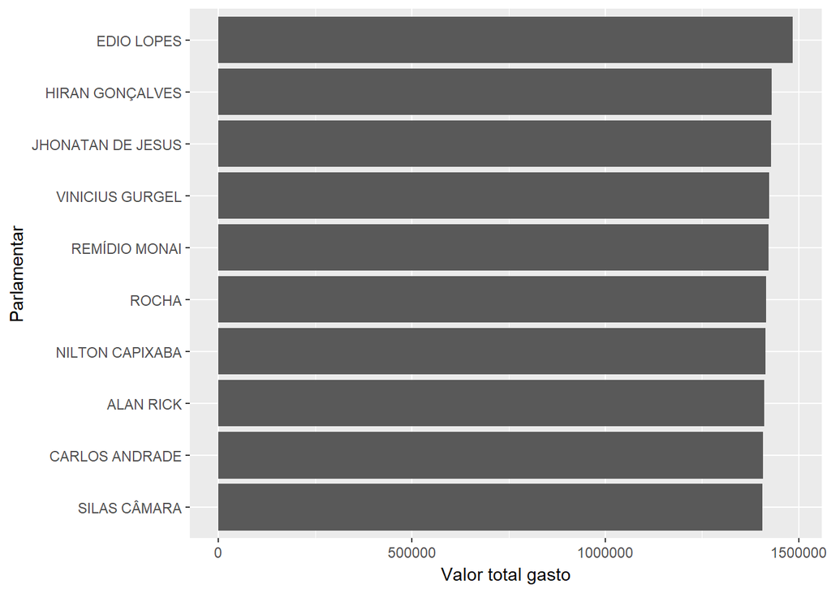

```r
ggplot(dep_mais_gastam, aes(x = reorder(nomeParlamentar, gasto_total_dep), y = gasto_total_dep), options(scipen=5)) +
    geom_bar(stat = "identity") +
    xlab("Parlamentar") + #eixo X
    ylab("Valor total gasto") + #eixo Y
    coord_flip()
```

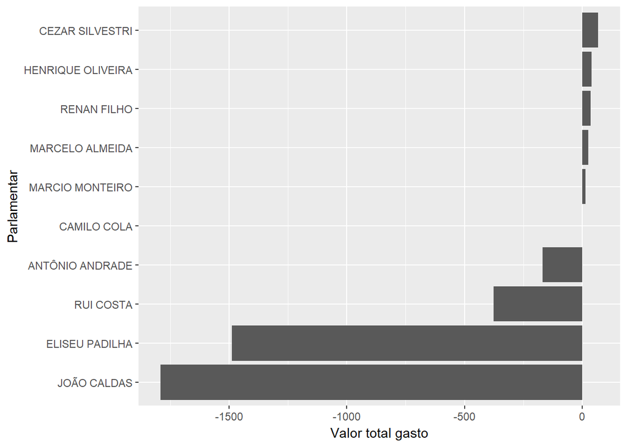

```r
ggplot(dep_menos_gastam, aes(x = reorder(nomeParlamentar, gasto_total_dep), y = gasto_total_dep), options(scipen=5)) +
    geom_bar(stat = "identity") +
    xlab("Parlamentar") + #eixo X
    ylab("Valor total gasto") + #eixo Y
    coord_flip()
```

5. Existe correlação entre a quantidade de gastos no exterior e o valor restituído da CEAP?

Extraindo os dados dos gastos no exterior dos deputados e o gasto total de cada deputado:

```r
gastos_exterior <- dadosCEAP %>%
  filter(tipoDocumento == "2") %>%
  group_by(nomeParlamentar) %>%
  summarise(soma_gasto_exterior = sum(valorLíquido))

gastos_dep <- dadosCEAP %>%
  group_by(nomeParlamentar) %>%
  summarise(soma_gasto = sum(valorLíquido))

gastos_total_exterior <- inner_join(gastos_exterior, gastos_dep)
```

Plotando-se o gráfico de correlação:

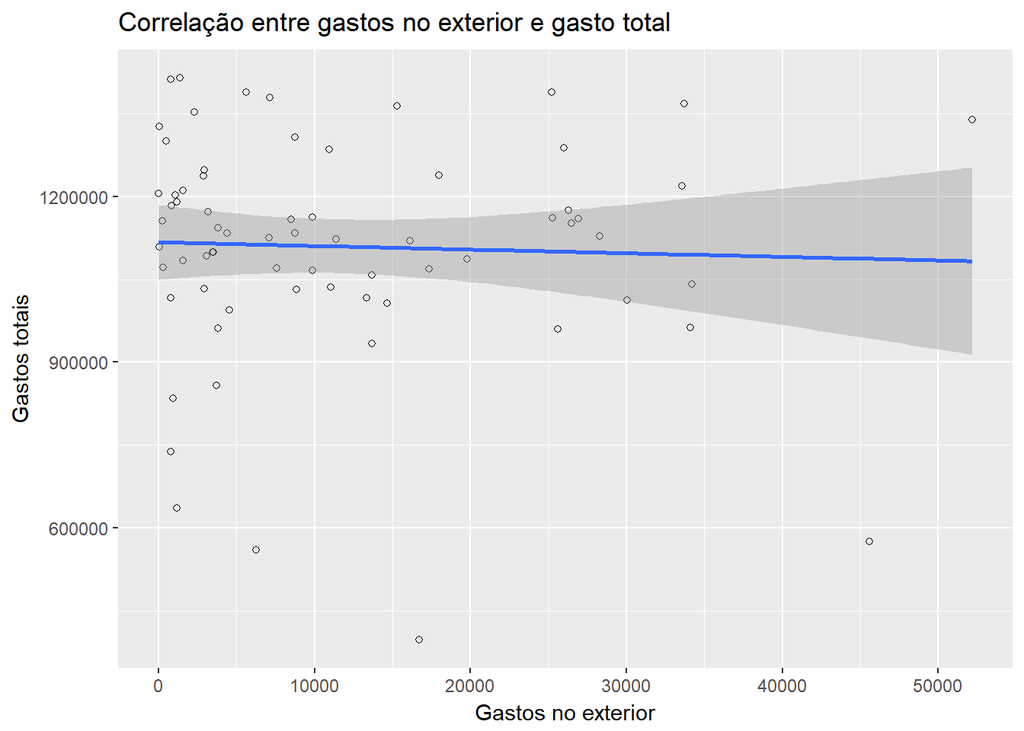

```r
ggplot(gastos_total_exterior, aes(x=soma_gasto_exterior, y=soma_gasto )) +
    geom_point(shape=1) +
    geom_smooth(method=lm) +
  labs(title = "Correlação entre gastos no exterior e gasto total", x = "Gastos no exterior", y = "Gastos totais")
```